# R Tutorial 007: forcats

RichardOnData

10/2/2020

```r
library(tidyverse)
```

We will explore the “forcats” package of the tidyverse. In this tutorial we will examine the following things:

1. Factors and their levels
2. Modifying factor order
3. Modifying factor levels

Please note that some of the code in this tutorial was adapted from Chapter 16 of the book “R for Data Science” by Hadley Wickham and Garrett Grolemund. The full book can be found at: https://r4ds.had.co.nz/#

A good cheat sheet for forcats functions can be found at: https://rstudio.com/resources/cheatsheets/

Another good tutorial for forcats: https://www.r-bloggers.com/2020/06/working-with-factors-in-r-tutorial-forcats-package/

### Factors and their levels

Let’s look at the motivation for factors.

```r
x1 <- c("Dec", "Apr", "Mar", "Jan")
x2 <- c("Dec", "Apr", "Mar", "Jam")   # This has a typo
```

It is important to define the levels of factors. Because we are looking at month variables, our levels are the various months.

```r
month_levels <- c("Jan", "Feb", "Mar", "Apr", "May", "Jun",
                  "Jul", "Aug", "Sep", "Oct", "Nov", "Dec")
```

Now let’s see what happens when we pass these levels to the levels argument of the `factor()` function.

```r
y1 <- factor(x1, levels = month_levels)
y1
```

```
## [1] Dec Apr Mar Jan
## Levels: Jan Feb Mar Apr May Jun Jul Aug Sep Oct Nov Dec
```

```r
y2 <- factor(x2, levels = month_levels)
y2
```

```
## [1] Dec  Apr  Mar  <NA>
## Levels: Jan Feb Mar Apr May Jun Jul Aug Sep Oct Nov Dec
```

Notice that in the `y2` factor, the “Jam” typo has been dropped.

By default, if you create a factor variable but do not specify the levels, the levels will be in alphabetical order.

```r
f1 <- factor(x1)
f1
```

```
## [1] Dec Apr Mar Jan
## Levels: Apr Dec Jan Mar
```

Alternatively, you can use the `unique()` function in the following, and the levels will be ordered in the order they appear in the data:

```r
o1 <- factor(x1, levels = unique(x1))
```

It is clearest to see how important the order of levels is in graphs. Let’s generate some fake data as “counts” and generate some bar charts to see the real-world impact of the order of factor levels.

```r
set.seed(36)
counts <- rnorm(4, 50, 10)
```

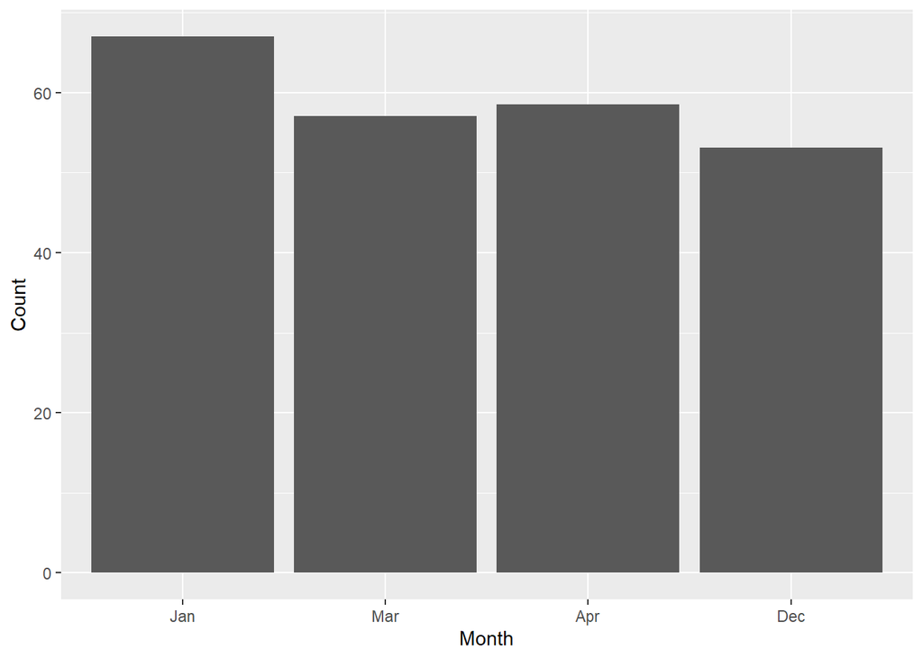

```r
orderedData <- data.frame(Month = y1, Count = counts)
ggplot(orderedData) +
  geom_bar(aes(x = Month, y = Count), stat = "identity")
```

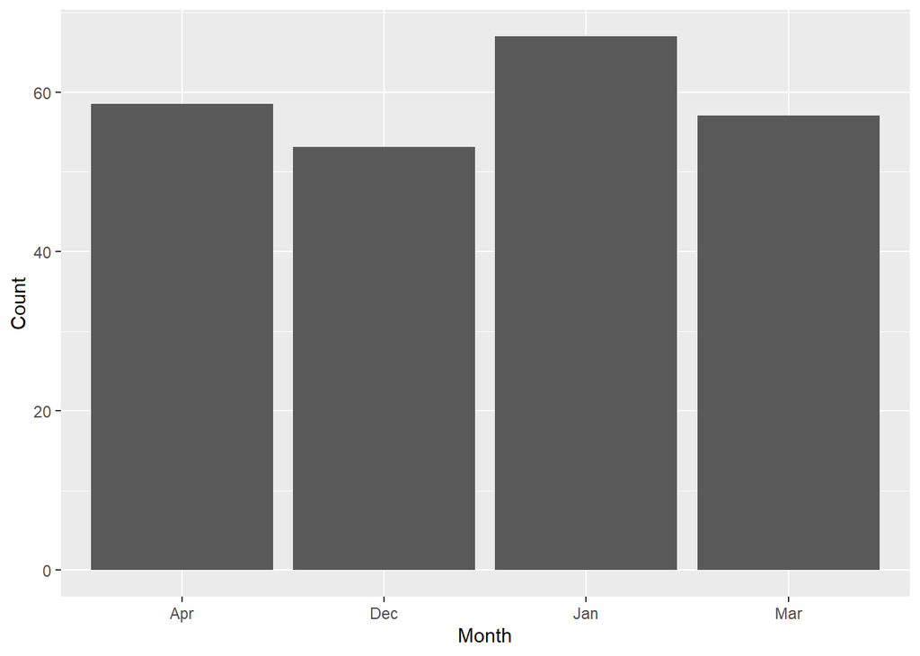

```r
alphabeticalData <- data.frame(Month = f1, Count = counts)
ggplot(alphabeticalData) +
  geom_bar(aes(x = Month, y = Count), stat = "identity")
```

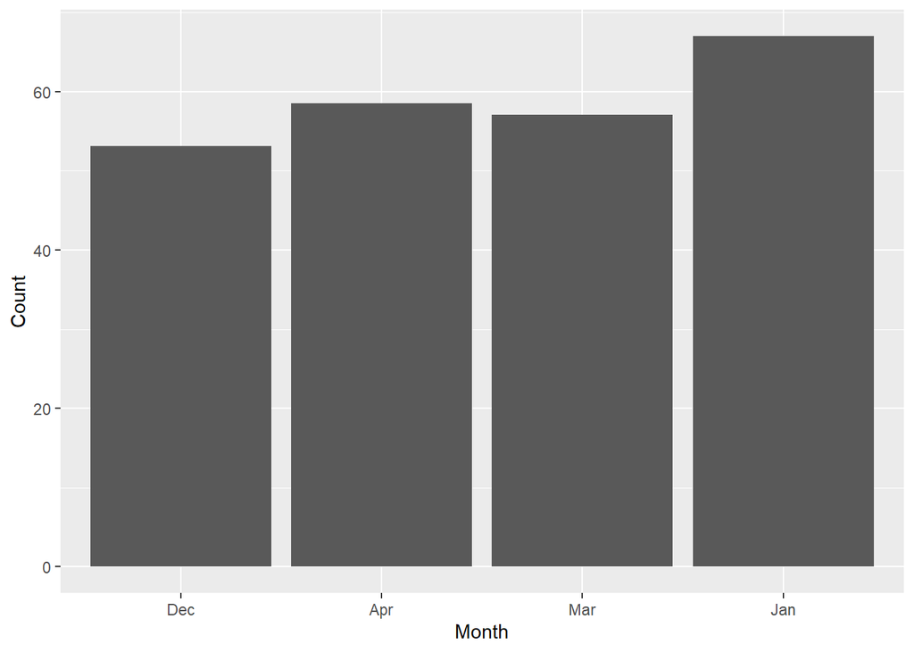

```r
firstAppearanceData <- data.frame(Month = o1, Count = counts)
ggplot(firstAppearanceData) +
  geom_bar(aes(x = Month, y = Count), stat = "identity")
```

### Modifying factor order

The forcats package has a number of helper functions, most of which involve either modifying the order of factor levels, or the levels themselves. We will start the factor order. We will use the dataset `gss_cat` which is built into the forcats package. Let’s start with the `count()` function. This is essentially a wrapper for the combination of `group_by()` followed by `tally()`, from the dplyr package. We will create and look at a new data frame, then create a tally by level of the variable “marital”.

```r
data <- gss_cat
head(data)
```

```
## # A tibble: 6 x 9
##    year marital      age race  rincome    partyid     relig     denom    tvhours
##   <int> <fct>      <int> <fct> <fct>      <fct>       <fct>     <fct>      <int>
## 1  2000 Never mar~    26 White $8000 to ~ Ind,near r~ Protesta~ Souther~      12
## 2  2000 Divorced      48 White $8000 to ~ Not str re~ Protesta~ Baptist~      NA
## 3  2000 Widowed       67 White Not appli~ Independent Protesta~ No deno~       2
## 4  2000 Never mar~    39 White Not appli~ Ind,near r~ Orthodox~ Not app~       4
## 5  2000 Divorced      25 White Not appli~ Not str de~ None      Not app~       1
## 6  2000 Married       25 White $20000 - ~ Strong dem~ Protesta~ Souther~      NA
```

```r
data %>%
  count(marital)
```

```
## # A tibble: 6 x 2
##   marital           n
##   <fct>         <int>
## 1 No answer        17
## 2 Never married  5416
## 3 Separated       743
## 4 Divorced       3383
## 5 Widowed        1807
## 6 Married       10117
```

Alternatively, you can use the `add_count()` function to add these directly to the original data.

```r
data %>%
  add_count(marital, name = "MaritalCount")
```

```
## # A tibble: 21,483 x 10
##     year marital    age race  rincome  partyid  relig denom tvhours MaritalCount
##    <int> <fct>    <int> <fct> <fct>    <fct>    <fct> <fct>   <int>        <int>
##  1  2000 Never m~    26 White $8000 t~ Ind,nea~ Prot~ Sout~      12         5416
##  2  2000 Divorced    48 White $8000 t~ Not str~ Prot~ Bapt~      NA         3383
##  3  2000 Widowed     67 White Not app~ Indepen~ Prot~ No d~       2         1807
##  4  2000 Never m~    39 White Not app~ Ind,nea~ Orth~ Not ~       4         5416
##  5  2000 Divorced    25 White Not app~ Not str~ None  Not ~       1         3383
##  6  2000 Married     25 White $20000 ~ Strong ~ Prot~ Sout~      NA        10117
##  7  2000 Never m~    36 White $25000 ~ Not str~ Chri~ Not ~       3         5416
##  8  2000 Divorced    44 White $7000 t~ Ind,nea~ Prot~ Luth~      NA         3383
##  9  2000 Married     44 White $25000 ~ Not str~ Prot~ Other       0        10117
## 10  2000 Married     47 White $25000 ~ Strong ~ Prot~ Sout~       3        10117
## # ... with 21,473 more rows
```

Let’s look at a simple bar chart of this variable.

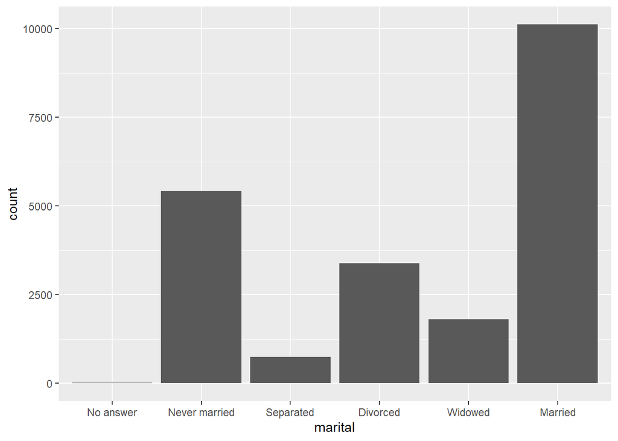

```r
data %>%
  ggplot() +
  geom_bar(aes(x = marital))
```

Notice these are out of order. We can use the `fct_infreq()` to reorder the levels of the factor from most to least frequent:

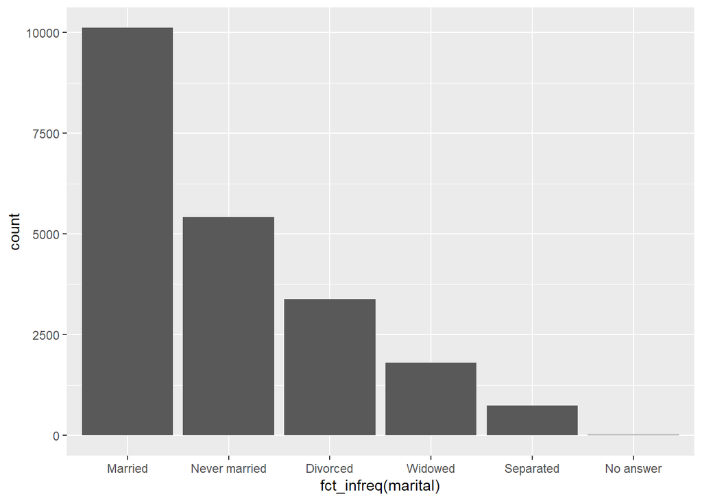

```r
data %>%
  ggplot() +
  geom_bar(aes(x = fct_infreq(marital)))
```

However, you may wish to have these in reverse order. We can use the `fct_rev()` function to reverse the current order of factor levels; thus these functions work incredibly well together. We will use the `mutate()` function to alter the actual data.

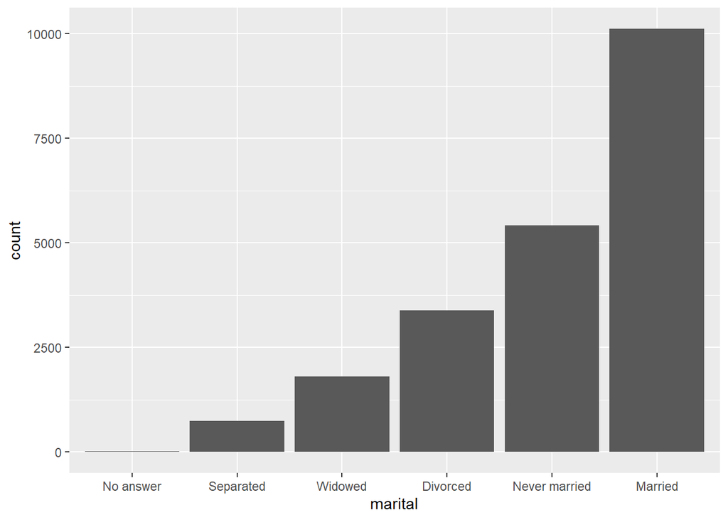

```r
data %>%
  mutate(marital = marital %>% fct_infreq() %>% fct_rev()) %>%
  ggplot() +
  geom_bar(aes(x = marital))
```

Next, we are going to use the `fct_reorder()` function, which helps to change the order of the levels of factors by another variable. We will do this with the variable “relig”, and start by creating a summary dataframe based on this variable.

```r
relig_summary <- data %>%
  group_by(relig) %>%
  summarise(
    age = mean(age, na.rm = TRUE),
    tvhours = mean(tvhours, na.rm = TRUE),
    n = n()
  )
relig_summary
```

```
## # A tibble: 15 x 4
##    relig                     age tvhours     n
##    <fct>                   <dbl>   <dbl> <int>
##  1 No answer                49.5    2.72    93
##  2 Don't know               35.9    4.62    15
##  3 Inter-nondenominational  40.0    2.87   109
##  4 Native american          38.9    3.46    23
##  5 Christian                40.1    2.79   689
##  6 Orthodox-christian       50.4    2.42    95
##  7 Moslem/islam             37.6    2.44   104
##  8 Other eastern            45.9    1.67    32
##  9 Hinduism                 37.7    1.89    71
## 10 Buddhism                 44.7    2.38   147
## 11 Other                    41.0    2.73   224
## 12 None                     41.2    2.71  3523
## 13 Jewish                   52.4    2.52   388
## 14 Catholic                 46.9    2.96  5124
## 15 Protestant               49.9    3.15 10846
```

Let’s create a scatterplot of TV hours by religion to see a relationship:

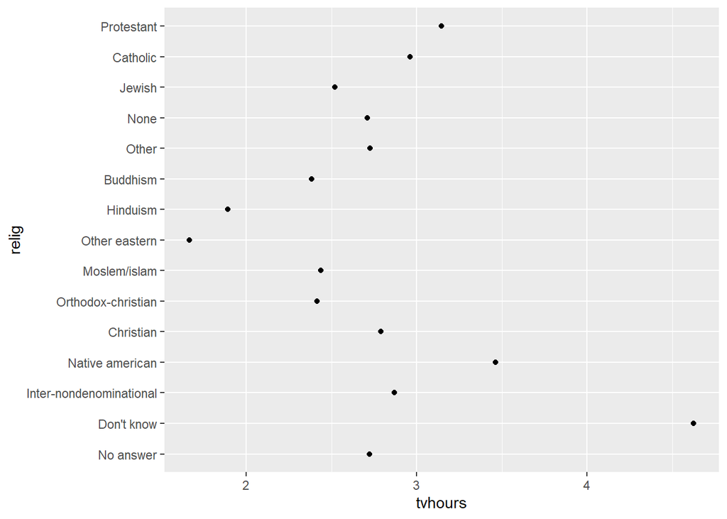

```r
ggplot(relig_summary, aes(tvhours, relig)) + geom_point()
```

Let’s rearrange using the `fct_reorder()` function:

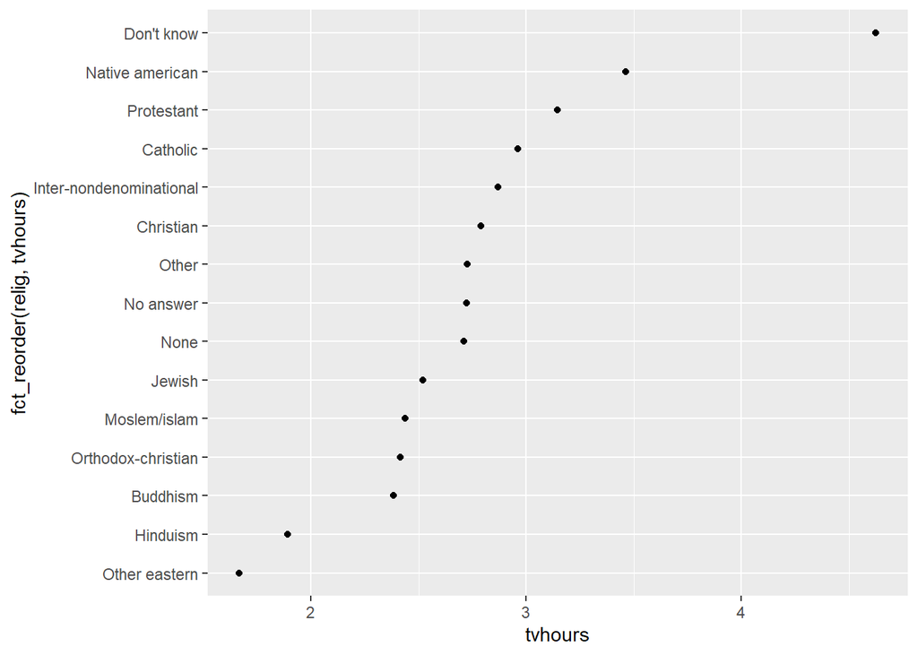

```r
ggplot(relig_summary, aes(tvhours, fct_reorder(relig, tvhours))) + geom_point()
```

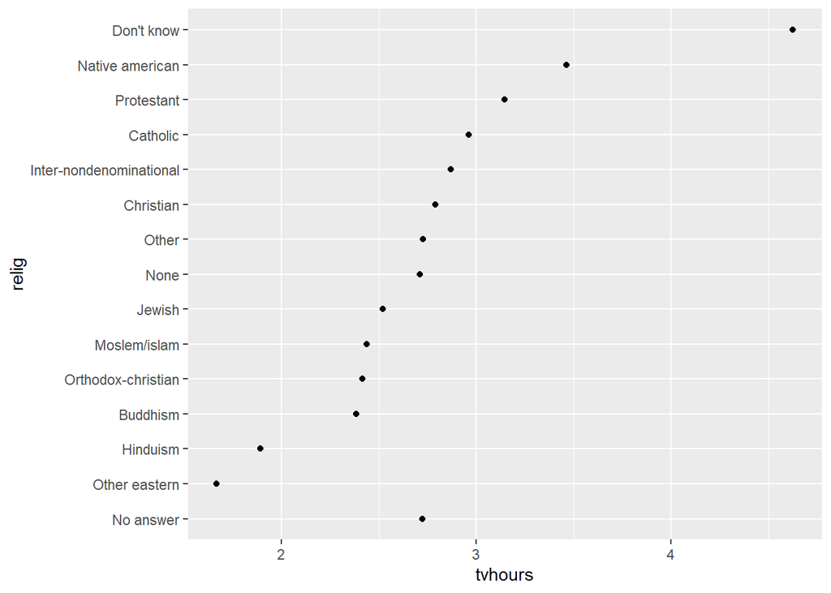

```r
relig_summary <- relig_summary %>%
  mutate(relig = fct_reorder(relig, tvhours)) %>%
  mutate(relig = fct_relevel(relig, "No answer"))
ggplot(relig_summary, aes(tvhours, relig)) + geom_point()
```

### Modifying factor levels

Next, we can actually recode and modify the levels of factors. Let’s look at the “partyid” variable.

```r
data %>%
  count(partyid)
```

```
## # A tibble: 10 x 2
##    partyid                n
##    <fct>              <int>
##  1 No answer            154
##  2 Don't know             1
##  3 Other party          393
##  4 Strong republican   2314
##  5 Not str republican  3032
##  6 Ind,near rep        1791
##  7 Independent         4119
##  8 Ind,near dem        2499
##  9 Not str democrat    3690
## 10 Strong democrat     3490
```

Notice there are many levels of these factors. We can change the names of these levels using the `fct_recode()` function.

```r
data <- data %>%
  mutate(partyid = fct_recode(partyid,
    "Republican, strong"    = "Strong republican",
    "Republican, weak"      = "Not str republican",
    "Independent, near rep" = "Ind,near rep",
    "Independent, near dem" = "Ind,near dem",
    "Democrat, weak"        = "Not str democrat",
    "Democrat, strong"      = "Strong democrat"
  ))
data %>%
  count(partyid)
```

```
## # A tibble: 10 x 2
##    partyid                   n
##    <fct>                 <int>
##  1 No answer               154
##  2 Don't know                1
##  3 Other party             393
##  4 Republican, strong     2314
##  5 Republican, weak       3032
##  6 Independent, near rep  1791
##  7 Independent            4119
##  8 Independent, near dem  2499
##  9 Democrat, weak         3690
## 10 Democrat, strong       3490
```

These look a bit better. Next, we can collapse many levels into fewer using the `fct_collapse()` function.

```r
data <- data %>%
  mutate(partyid = fct_collapse(partyid,
    "other" = c("No answer", "Don't know", "Other party"),
    "republican" = c("Republican, strong", "Republican, weak"),
    "independent" = c("Independent, near rep", "Independent", "Independent, near dem"),
    "democrat" = c("Democrat, weak", "Democrat, strong")))
data %>%
  count(partyid)
```

```
## # A tibble: 4 x 2
##   partyid         n
##   <fct>       <int>
## 1 other         548
## 2 republican   5346
## 3 independent  8409
## 4 democrat     7180
```

Lastly, we have helper functions `fct_lump_min()`, `fct_lump_prop()`, `fct_lump_n()`, and `fct_lump_lowfreq()`. Definitions are as follows:

- `fct_lump_min()`: lumps levels that appear fewer than min times.
- `fct_lump_prop()`: lumps levels that appear in fewer prop * n times.
- `fct_lump_n()` lumps all levels except for the n most frequent (or least frequent if n < 0)
- `fct_lump_lowfreq()` lumps together the least frequent levels, ensuring that “other” is still the smallest level.

Let’s see an example with the `fct_lump_n()` function:

```r
data %>%
  mutate(marital = fct_lump_n(marital, n = 3)) %>%
  count(marital)
```

```
## # A tibble: 4 x 2
##   marital           n
##   <fct>         <int>
## 1 Never married  5416
## 2 Divorced       3383
## 3 Married       10117
## 4 Other          2567
```

This leaves the top three levels by frequency, and lumps everything else together into the “Other” category.